# Risk Factor Analysis

## Outcome Variable

**Outcome Variable:** ever_stunted

## Predictor Variables

**Intervention Variable:** lag_WHZ_quart

**Adjustment Set:**

- arm
- sex
- brthmon
- W_mage
- meducyrs
- feducyrs
- hhwealth_quart
- single
- month
- W_parity
- delta_W_mage
- delta_meducyrs
- delta_feducyrs
- delta_hhwealth_quart
- delta_single
- delta_month
- delta_W_parity

## Stratifying Variables

The analysis was stratified on these variable(s):

- agecat
- studyid
- country

## Data Summary

| agecat | studyid | country | lag_WHZ_quart | ever_stunted | n_cell | n |
| --- | --- | --- | --- | --- | --- | --- |
| 3-6 months | ki0047075b-MAL-ED | BANGLADESH | 1 | 0 | 30 | 207 |
| 3-6 months | ki0047075b-MAL-ED | BANGLADESH | 1 | 1 | 4 | 207 |
| 3-6 months | ki0047075b-MAL-ED | BANGLADESH | 2 | 0 | 79 | 207 |
| 3-6 months | ki0047075b-MAL-ED | BANGLADESH | 2 | 1 | 11 | 207 |
| 3-6 months | ki0047075b-MAL-ED | BANGLADESH | 3 | 0 | 61 | 207 |
| 3-6 months | ki0047075b-MAL-ED | BANGLADESH | 3 | 1 | 13 | 207 |
| 3-6 months | ki0047075b-MAL-ED | BANGLADESH | 4 | 0 | 9 | 207 |
| 3-6 months | ki0047075b-MAL-ED | BANGLADESH | 4 | 1 | 0 | 207 |
| 3-6 months | ki0047075b-MAL-ED | BRAZIL | 1 | 0 | 33 | 197 |
| 3-6 months | ki0047075b-MAL-ED | BRAZIL | 1 | 1 | 2 | 197 |
| 3-6 months | ki0047075b-MAL-ED | BRAZIL | 2 | 0 | 86 | 197 |
| 3-6 months | ki0047075b-MAL-ED | BRAZIL | 2 | 1 | 5 | 197 |
| 3-6 months | ki0047075b-MAL-ED | BRAZIL | 3 | 0 | 56 | 197 |
| 3-6 months | ki0047075b-MAL-ED | BRAZIL | 3 | 1 | 3 | 197 |
| 3-6 months | ki0047075b-MAL-ED | BRAZIL | 4 | 0 | 9 | 197 |
| 3-6 months | ki0047075b-MAL-ED | BRAZIL | 4 | 1 | 3 | 197 |
| 3-6 months | ki0047075b-MAL-ED | INDIA | 1 | 0 | 87 | 200 |
| 3-6 months | ki0047075b-MAL-ED | INDIA | 1 | 1 | 17 | 200 |
| 3-6 months | ki0047075b-MAL-ED | INDIA | 2 | 0 | 64 | 200 |
| 3-6 months | ki0047075b-MAL-ED | INDIA | 2 | 1 | 11 | 200 |
| 3-6 months | ki0047075b-MAL-ED | INDIA | 3 | 0 | 13 | 200 |
| 3-6 months | ki0047075b-MAL-ED | INDIA | 3 | 1 | 8 | 200 |
| 3-6 months | ki0047075b-MAL-ED | INDIA | 4 | 0 | 0 | 200 |
| 3-6 months | ki0047075b-MAL-ED | INDIA | 4 | 1 | 0 | 200 |
| 3-6 months | ki0047075b-MAL-ED | NEPAL | 1 | 0 | 68 | 209 |
| 3-6 months | ki0047075b-MAL-ED | NEPAL | 1 | 1 | 1 | 209 |
| 3-6 months | ki0047075b-MAL-ED | NEPAL | 2 | 0 | 75 | 209 |
| 3-6 months | ki0047075b-MAL-ED | NEPAL | 2 | 1 | 2 | 209 |
| 3-6 months | ki0047075b-MAL-ED | NEPAL | 3 | 0 | 49 | 209 |
| 3-6 months | ki0047075b-MAL-ED | NEPAL | 3 | 1 | 1 | 209 |

[output cut: 818 more lines]

The following strata were considered:

- agecat: 12-15 months, studyid: ki0047075b-MAL-ED, country: BANGLADESH
- agecat: 12-15 months, studyid: ki0047075b-MAL-ED, country: BRAZIL
- agecat: 12-15 months, studyid: ki0047075b-MAL-ED, country: INDIA
- agecat: 12-15 months, studyid: ki0047075b-MAL-ED, country: NEPAL
- agecat: 12-15 months, studyid: ki0047075b-MAL-ED, country: PERU
- agecat: 12-15 months, studyid: ki0047075b-MAL-ED, country: SOUTH AFRICA
- agecat: 12-15 months, studyid: ki0047075b-MAL-ED, country: TANZANIA, UNITED REPUBLIC OF
- agecat: 12-15 months, studyid: ki1000108-CMC-V-BCS-2002, country: INDIA
- agecat: 12-15 months, studyid: ki1000108-IRC, country: INDIA
- agecat: 12-15 months, studyid: ki1000109-ResPak, country: PAKISTAN
- agecat: 12-15 months, studyid: ki1017093b-PROVIDE, country: BANGLADESH
- agecat: 12-15 months, studyid: ki1066203-TanzaniaChild2, country: TANZANIA, UNITED REPUBLIC OF
- agecat: 12-15 months, studyid: ki1101329-Keneba, country: GAMBIA
- agecat: 12-15 months, studyid: ki1112895-Guatemala BSC, country: GUATEMALA
- agecat: 12-15 months, studyid: ki1113344-GMS-Nepal, country: NEPAL
- agecat: 12-15 months, studyid: ki1114097-CMIN, country: BANGLADESH
- agecat: 15-18 months, studyid: ki0047075b-MAL-ED, country: BANGLADESH
- agecat: 15-18 months, studyid: ki0047075b-MAL-ED, country: BRAZIL
- agecat: 15-18 months, studyid: ki0047075b-MAL-ED, country: INDIA
- agecat: 15-18 months, studyid: ki0047075b-MAL-ED, country: NEPAL
- agecat: 15-18 months, studyid: ki0047075b-MAL-ED, country: PERU
- agecat: 15-18 months, studyid: ki0047075b-MAL-ED, country: SOUTH AFRICA
- agecat: 15-18 months, studyid: ki0047075b-MAL-ED, country: TANZANIA, UNITED REPUBLIC OF
- agecat: 15-18 months, studyid: ki1000108-CMC-V-BCS-2002, country: INDIA
- agecat: 15-18 months, studyid: ki1000108-IRC, country: INDIA
- agecat: 15-18 months, studyid: ki1000109-ResPak, country: PAKISTAN
- agecat: 15-18 months, studyid: ki1017093b-PROVIDE, country: BANGLADESH
- agecat: 15-18 months, studyid: ki1066203-TanzaniaChild2, country: TANZANIA, UNITED REPUBLIC OF
- agecat: 15-18 months, studyid: ki1101329-Keneba, country: GAMBIA
- agecat: 15-18 months, studyid: ki1112895-Guatemala BSC, country: GUATEMALA
- agecat: 15-18 months, studyid: ki1113344-GMS-Nepal, country: NEPAL
- agecat: 15-18 months, studyid: ki1114097-CMIN, country: BANGLADESH
- agecat: 18-21 months, studyid: ki0047075b-MAL-ED, country: BANGLADESH
- agecat: 18-21 months, studyid: ki0047075b-MAL-ED, country: BRAZIL
- agecat: 18-21 months, studyid: ki0047075b-MAL-ED, country: INDIA
- agecat: 18-21 months, studyid: ki0047075b-MAL-ED, country: NEPAL
- agecat: 18-21 months, studyid: ki0047075b-MAL-ED, country: PERU
- agecat: 18-21 months, studyid: ki0047075b-MAL-ED, country: SOUTH AFRICA
- agecat: 18-21 months, studyid: ki0047075b-MAL-ED, country: TANZANIA, UNITED REPUBLIC OF
- agecat: 18-21 months, studyid: ki1000108-CMC-V-BCS-2002, country: INDIA
- agecat: 18-21 months, studyid: ki1000108-IRC, country: INDIA
- agecat: 18-21 months, studyid: ki1017093b-PROVIDE, country: BANGLADESH
- agecat: 18-21 months, studyid: ki1066203-TanzaniaChild2, country: TANZANIA, UNITED REPUBLIC OF
- agecat: 18-21 months, studyid: ki1101329-Keneba, country: GAMBIA
- agecat: 18-21 months, studyid: ki1113344-GMS-Nepal, country: NEPAL
- agecat: 18-21 months, studyid: ki1114097-CMIN, country: BANGLADESH
- agecat: 21-24 months, studyid: ki0047075b-MAL-ED, country: BANGLADESH
- agecat: 21-24 months, studyid: ki0047075b-MAL-ED, country: BRAZIL
- agecat: 21-24 months, studyid: ki0047075b-MAL-ED, country: INDIA
- agecat: 21-24 months, studyid: ki0047075b-MAL-ED, country: NEPAL
- agecat: 21-24 months, studyid: ki0047075b-MAL-ED, country: PERU
- agecat: 21-24 months, studyid: ki0047075b-MAL-ED, country: SOUTH AFRICA
- agecat: 21-24 months, studyid: ki0047075b-MAL-ED, country: TANZANIA, UNITED REPUBLIC OF
- agecat: 21-24 months, studyid: ki1000108-CMC-V-BCS-2002, country: INDIA
- agecat: 21-24 months, studyid: ki1000108-IRC, country: INDIA
- agecat: 21-24 months, studyid: ki1017093b-PROVIDE, country: BANGLADESH
- agecat: 21-24 months, studyid: ki1066203-TanzaniaChild2, country: TANZANIA, UNITED REPUBLIC OF
- agecat: 21-24 months, studyid: ki1101329-Keneba, country: GAMBIA
- agecat: 21-24 months, studyid: ki1113344-GMS-Nepal, country: NEPAL
- agecat: 21-24 months, studyid: ki1114097-CMIN, country: BANGLADESH
- agecat: 3-6 months, studyid: ki0047075b-MAL-ED, country: BANGLADESH
- agecat: 3-6 months, studyid: ki0047075b-MAL-ED, country: BRAZIL
- agecat: 3-6 months, studyid: ki0047075b-MAL-ED, country: INDIA
- agecat: 3-6 months, studyid: ki0047075b-MAL-ED, country: NEPAL
- agecat: 3-6 months, studyid: ki0047075b-MAL-ED, country: PERU
- agecat: 3-6 months, studyid: ki0047075b-MAL-ED, country: SOUTH AFRICA
- agecat: 3-6 months, studyid: ki0047075b-MAL-ED, country: TANZANIA, UNITED REPUBLIC OF
- agecat: 3-6 months, studyid: ki1000108-CMC-V-BCS-2002, country: INDIA
- agecat: 3-6 months, studyid: ki1000108-IRC, country: INDIA
- agecat: 3-6 months, studyid: ki1000109-ResPak, country: PAKISTAN
- agecat: 3-6 months, studyid: ki1017093b-PROVIDE, country: BANGLADESH
- agecat: 3-6 months, studyid: ki1066203-TanzaniaChild2, country: TANZANIA, UNITED REPUBLIC OF
- agecat: 3-6 months, studyid: ki1101329-Keneba, country: GAMBIA
- agecat: 3-6 months, studyid: ki1112895-Guatemala BSC, country: GUATEMALA
- agecat: 3-6 months, studyid: ki1114097-CMIN, country: BANGLADESH
- agecat: 6-9 months, studyid: ki0047075b-MAL-ED, country: BANGLADESH
- agecat: 6-9 months, studyid: ki0047075b-MAL-ED, country: BRAZIL
- agecat: 6-9 months, studyid: ki0047075b-MAL-ED, country: INDIA
- agecat: 6-9 months, studyid: ki0047075b-MAL-ED, country: NEPAL
- agecat: 6-9 months, studyid: ki0047075b-MAL-ED, country: PERU
- agecat: 6-9 months, studyid: ki0047075b-MAL-ED, country: SOUTH AFRICA
- agecat: 6-9 months, studyid: ki0047075b-MAL-ED, country: TANZANIA, UNITED REPUBLIC OF
- agecat: 6-9 months, studyid: ki1000108-CMC-V-BCS-2002, country: INDIA
- agecat: 6-9 months, studyid: ki1000108-IRC, country: INDIA
- agecat: 6-9 months, studyid: ki1000109-ResPak, country: PAKISTAN
- agecat: 6-9 months, studyid: ki1017093b-PROVIDE, country: BANGLADESH
- agecat: 6-9 months, studyid: ki1066203-TanzaniaChild2, country: TANZANIA, UNITED REPUBLIC OF
- agecat: 6-9 months, studyid: ki1101329-Keneba, country: GAMBIA
- agecat: 6-9 months, studyid: ki1112895-Guatemala BSC, country: GUATEMALA
- agecat: 6-9 months, studyid: ki1114097-CMIN, country: BANGLADESH
- agecat: 9-12 months, studyid: ki0047075b-MAL-ED, country: BANGLADESH
- agecat: 9-12 months, studyid: ki0047075b-MAL-ED, country: BRAZIL
- agecat: 9-12 months, studyid: ki0047075b-MAL-ED, country: INDIA
- agecat: 9-12 months, studyid: ki0047075b-MAL-ED, country: NEPAL
- agecat: 9-12 months, studyid: ki0047075b-MAL-ED, country: PERU
- agecat: 9-12 months, studyid: ki0047075b-MAL-ED, country: SOUTH AFRICA
- agecat: 9-12 months, studyid: ki0047075b-MAL-ED, country: TANZANIA, UNITED REPUBLIC OF
- agecat: 9-12 months, studyid: ki1000108-CMC-V-BCS-2002, country: INDIA
- agecat: 9-12 months, studyid: ki1000108-IRC, country: INDIA
- agecat: 9-12 months, studyid: ki1000109-ResPak, country: PAKISTAN
- agecat: 9-12 months, studyid: ki1017093b-PROVIDE, country: BANGLADESH
- agecat: 9-12 months, studyid: ki1066203-TanzaniaChild2, country: TANZANIA, UNITED REPUBLIC OF
- agecat: 9-12 months, studyid: ki1101329-Keneba, country: GAMBIA
- agecat: 9-12 months, studyid: ki1112895-Guatemala BSC, country: GUATEMALA
- agecat: 9-12 months, studyid: ki1113344-GMS-Nepal, country: NEPAL
- agecat: 9-12 months, studyid: ki1114097-CMIN, country: BANGLADESH

### Dropped Strata

Some strata were dropped due to rare outcomes:

- agecat: 3-6 months, studyid: ki0047075b-MAL-ED, country: BANGLADESH
- agecat: 3-6 months, studyid: ki0047075b-MAL-ED, country: BRAZIL
- agecat: 3-6 months, studyid: ki0047075b-MAL-ED, country: INDIA
- agecat: 3-6 months, studyid: ki0047075b-MAL-ED, country: NEPAL
- agecat: 3-6 months, studyid: ki0047075b-MAL-ED, country: PERU
- agecat: 3-6 months, studyid: ki0047075b-MAL-ED, country: SOUTH AFRICA
- agecat: 3-6 months, studyid: ki1000108-CMC-V-BCS-2002, country: INDIA
- agecat: 3-6 months, studyid: ki1000108-IRC, country: INDIA
- agecat: 3-6 months, studyid: ki1112895-Guatemala BSC, country: GUATEMALA
- agecat: 3-6 months, studyid: ki1114097-CMIN, country: BANGLADESH
- agecat: 6-9 months, studyid: ki0047075b-MAL-ED, country: BANGLADESH
- agecat: 6-9 months, studyid: ki0047075b-MAL-ED, country: BRAZIL
- agecat: 6-9 months, studyid: ki0047075b-MAL-ED, country: INDIA
- agecat: 6-9 months, studyid: ki0047075b-MAL-ED, country: NEPAL
- agecat: 6-9 months, studyid: ki0047075b-MAL-ED, country: PERU
- agecat: 6-9 months, studyid: ki1000108-CMC-V-BCS-2002, country: INDIA
- agecat: 6-9 months, studyid: ki1000108-IRC, country: INDIA
- agecat: 6-9 months, studyid: ki1000109-ResPak, country: PAKISTAN
- agecat: 6-9 months, studyid: ki1017093b-PROVIDE, country: BANGLADESH
- agecat: 6-9 months, studyid: ki1114097-CMIN, country: BANGLADESH
- agecat: 9-12 months, studyid: ki0047075b-MAL-ED, country: BANGLADESH
- agecat: 9-12 months, studyid: ki0047075b-MAL-ED, country: BRAZIL
- agecat: 9-12 months, studyid: ki0047075b-MAL-ED, country: INDIA
- agecat: 9-12 months, studyid: ki0047075b-MAL-ED, country: NEPAL
- agecat: 9-12 months, studyid: ki0047075b-MAL-ED, country: PERU
- agecat: 9-12 months, studyid: ki0047075b-MAL-ED, country: SOUTH AFRICA
- agecat: 9-12 months, studyid: ki1000108-CMC-V-BCS-2002, country: INDIA
- agecat: 9-12 months, studyid: ki1000108-IRC, country: INDIA
- agecat: 9-12 months, studyid: ki1000109-ResPak, country: PAKISTAN
- agecat: 9-12 months, studyid: ki1017093b-PROVIDE, country: BANGLADESH
- agecat: 9-12 months, studyid: ki1101329-Keneba, country: GAMBIA
- agecat: 9-12 months, studyid: ki1113344-GMS-Nepal, country: NEPAL
- agecat: 9-12 months, studyid: ki1114097-CMIN, country: BANGLADESH
- agecat: 12-15 months, studyid: ki0047075b-MAL-ED, country: BANGLADESH
- agecat: 12-15 months, studyid: ki0047075b-MAL-ED, country: BRAZIL
- agecat: 12-15 months, studyid: ki0047075b-MAL-ED, country: INDIA
- agecat: 12-15 months, studyid: ki0047075b-MAL-ED, country: NEPAL
- agecat: 12-15 months, studyid: ki0047075b-MAL-ED, country: PERU
- agecat: 12-15 months, studyid: ki0047075b-MAL-ED, country: SOUTH AFRICA
- agecat: 12-15 months, studyid: ki1000108-CMC-V-BCS-2002, country: INDIA
- agecat: 12-15 months, studyid: ki1000108-IRC, country: INDIA
- agecat: 12-15 months, studyid: ki1000109-ResPak, country: PAKISTAN
- agecat: 12-15 months, studyid: ki1017093b-PROVIDE, country: BANGLADESH
- agecat: 12-15 months, studyid: ki1112895-Guatemala BSC, country: GUATEMALA
- agecat: 12-15 months, studyid: ki1113344-GMS-Nepal, country: NEPAL
- agecat: 12-15 months, studyid: ki1114097-CMIN, country: BANGLADESH
- agecat: 15-18 months, studyid: ki0047075b-MAL-ED, country: BANGLADESH
- agecat: 15-18 months, studyid: ki0047075b-MAL-ED, country: BRAZIL
- agecat: 15-18 months, studyid: ki0047075b-MAL-ED, country: INDIA
- agecat: 15-18 months, studyid: ki0047075b-MAL-ED, country: NEPAL
- agecat: 15-18 months, studyid: ki0047075b-MAL-ED, country: PERU
- agecat: 15-18 months, studyid: ki0047075b-MAL-ED, country: SOUTH AFRICA
- agecat: 15-18 months, studyid: ki0047075b-MAL-ED, country: TANZANIA, UNITED REPUBLIC OF
- agecat: 15-18 months, studyid: ki1000108-CMC-V-BCS-2002, country: INDIA
- agecat: 15-18 months, studyid: ki1000108-IRC, country: INDIA
- agecat: 15-18 months, studyid: ki1000109-ResPak, country: PAKISTAN
- agecat: 15-18 months, studyid: ki1017093b-PROVIDE, country: BANGLADESH
- agecat: 15-18 months, studyid: ki1101329-Keneba, country: GAMBIA
- agecat: 15-18 months, studyid: ki1112895-Guatemala BSC, country: GUATEMALA
- agecat: 15-18 months, studyid: ki1113344-GMS-Nepal, country: NEPAL
- agecat: 15-18 months, studyid: ki1114097-CMIN, country: BANGLADESH
- agecat: 18-21 months, studyid: ki0047075b-MAL-ED, country: BANGLADESH
- agecat: 18-21 months, studyid: ki0047075b-MAL-ED, country: BRAZIL
- agecat: 18-21 months, studyid: ki0047075b-MAL-ED, country: INDIA
- agecat: 18-21 months, studyid: ki0047075b-MAL-ED, country: NEPAL
- agecat: 18-21 months, studyid: ki0047075b-MAL-ED, country: PERU
- agecat: 18-21 months, studyid: ki0047075b-MAL-ED, country: SOUTH AFRICA
- agecat: 18-21 months, studyid: ki0047075b-MAL-ED, country: TANZANIA, UNITED REPUBLIC OF
- agecat: 18-21 months, studyid: ki1000108-CMC-V-BCS-2002, country: INDIA
- agecat: 18-21 months, studyid: ki1000108-IRC, country: INDIA
- agecat: 18-21 months, studyid: ki1017093b-PROVIDE, country: BANGLADESH
- agecat: 18-21 months, studyid: ki1066203-TanzaniaChild2, country: TANZANIA, UNITED REPUBLIC OF
- agecat: 18-21 months, studyid: ki1101329-Keneba, country: GAMBIA
- agecat: 18-21 months, studyid: ki1113344-GMS-Nepal, country: NEPAL
- agecat: 18-21 months, studyid: ki1114097-CMIN, country: BANGLADESH
- agecat: 21-24 months, studyid: ki0047075b-MAL-ED, country: BANGLADESH
- agecat: 21-24 months, studyid: ki0047075b-MAL-ED, country: BRAZIL
- agecat: 21-24 months, studyid: ki0047075b-MAL-ED, country: INDIA
- agecat: 21-24 months, studyid: ki0047075b-MAL-ED, country: NEPAL
- agecat: 21-24 months, studyid: ki0047075b-MAL-ED, country: PERU
- agecat: 21-24 months, studyid: ki0047075b-MAL-ED, country: SOUTH AFRICA
- agecat: 21-24 months, studyid: ki0047075b-MAL-ED, country: TANZANIA, UNITED REPUBLIC OF
- agecat: 21-24 months, studyid: ki1000108-CMC-V-BCS-2002, country: INDIA
- agecat: 21-24 months, studyid: ki1000108-IRC, country: INDIA
- agecat: 21-24 months, studyid: ki1017093b-PROVIDE, country: BANGLADESH
- agecat: 21-24 months, studyid: ki1066203-TanzaniaChild2, country: TANZANIA, UNITED REPUBLIC OF
- agecat: 21-24 months, studyid: ki1113344-GMS-Nepal, country: NEPAL
- agecat: 21-24 months, studyid: ki1114097-CMIN, country: BANGLADESH

## Methods Detail

We’re interested in the causal parameters $E[Y_a]$ for all values of $a \in \mathcal{A}$. These parameters represent the mean outcome if, possibly contrary to fact, we intervened to set all units to have $A=a$. Under the randomization and positivity assumptions, these are identified by the statistical parameters $\psi_a=E_W[E_{Y|A,W}(Y|A=a,W)]$. In addition, we’re interested in the mean of $Y$, $E[Y]$ under no intervention (the observed mean). We will estimate these parameters by using SuperLearner to fit the relevant likelihood factors – $E_{Y|A,W}(Y|A=a,W)$ and $p(A=a|W)$, and then updating our likelihood fit using a joint TMLE.

For unadjusted analyses ($W=\{\}$), initial likelihoods were estimated using Lrnr_glm to estimate the simple $E(Y|A)$ and Lrnr_mean to estimate $p(A)$. For adjusted analyses, a small library containing Lrnr_glmnet, Lrnr_xgboost, and Lrnr_mean was used.

Having estimated these parameters, we will then use the delta method to estimate relative risks and attributable risks relative to a prespecified baseline level of $A$.

# Results Detail

## Results Plots

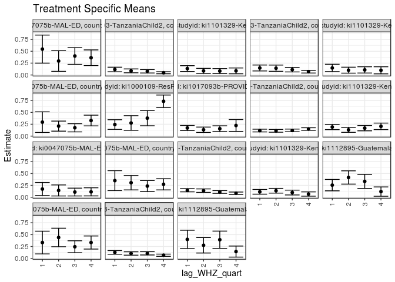

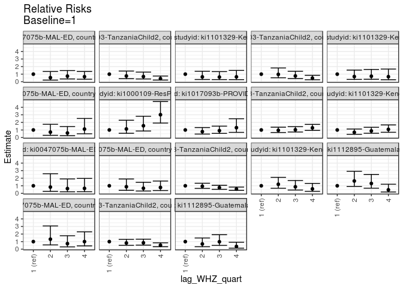

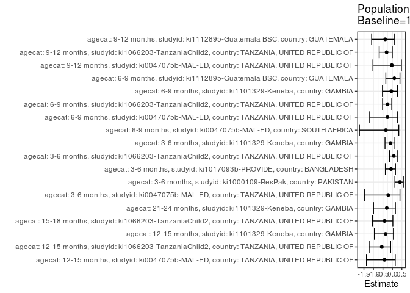

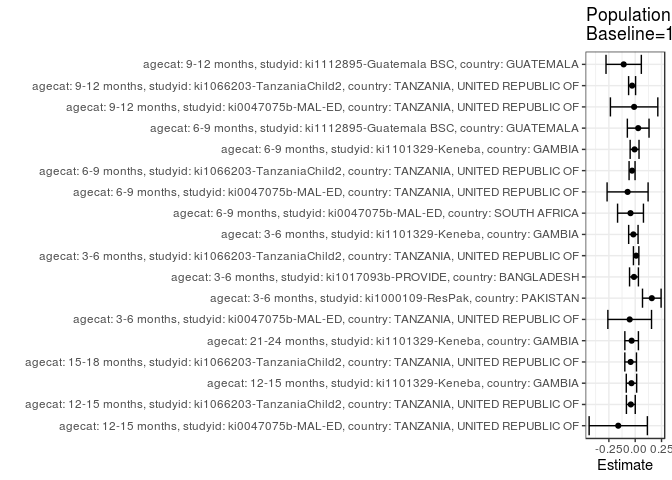

## Results Table

### Parameter: TSM

| agecat | studyid | country | intervention_level | baseline_level | estimate | ci_lower | ci_upper |
| --- | --- | --- | --- | --- | --- | --- | --- |
| 3-6 months | ki0047075b-MAL-ED | TANZANIA, UNITED REPUBLIC OF | 1 | NA | 0.2941176 | 0.0770162 | 0.5112191 |
| 3-6 months | ki0047075b-MAL-ED | TANZANIA, UNITED REPUBLIC OF | 2 | NA | 0.2105263 | 0.1044435 | 0.3166091 |
| 3-6 months | ki0047075b-MAL-ED | TANZANIA, UNITED REPUBLIC OF | 3 | NA | 0.1756757 | 0.0887697 | 0.2625816 |
| 3-6 months | ki0047075b-MAL-ED | TANZANIA, UNITED REPUBLIC OF | 4 | NA | 0.3283582 | 0.2156473 | 0.4410691 |
| 3-6 months | ki1000109-ResPak | PAKISTAN | 1 | NA | 0.2433820 | 0.1415401 | 0.3452238 |
| 3-6 months | ki1000109-ResPak | PAKISTAN | 2 | NA | 0.2759765 | 0.1214472 | 0.4305058 |
| 3-6 months | ki1000109-ResPak | PAKISTAN | 3 | NA | 0.3786013 | 0.2184908 | 0.5387118 |
| 3-6 months | ki1000109-ResPak | PAKISTAN | 4 | NA | 0.7339553 | 0.6020064 | 0.8659041 |
| 3-6 months | ki1017093b-PROVIDE | BANGLADESH | 1 | NA | 0.1712695 | 0.1179856 | 0.2245534 |
| 3-6 months | ki1017093b-PROVIDE | BANGLADESH | 2 | NA | 0.1334335 | 0.0768707 | 0.1899962 |
| 3-6 months | ki1017093b-PROVIDE | BANGLADESH | 3 | NA | 0.1559227 | 0.0940942 | 0.2177512 |
| 3-6 months | ki1017093b-PROVIDE | BANGLADESH | 4 | NA | 0.2234182 | 0.0975790 | 0.3492574 |
| 3-6 months | ki1066203-TanzaniaChild2 | TANZANIA, UNITED REPUBLIC OF | 1 | NA | 0.1168532 | 0.0879743 | 0.1457320 |
| 3-6 months | ki1066203-TanzaniaChild2 | TANZANIA, UNITED REPUBLIC OF | 2 | NA | 0.1113496 | 0.0822221 | 0.1404770 |
| 3-6 months | ki1066203-TanzaniaChild2 | TANZANIA, UNITED REPUBLIC OF | 3 | NA | 0.1197547 | 0.0912597 | 0.1482496 |
| 3-6 months | ki1066203-TanzaniaChild2 | TANZANIA, UNITED REPUBLIC OF | 4 | NA | 0.1494960 | 0.1227146 | 0.1762775 |
| 3-6 months | ki1101329-Keneba | GAMBIA | 1 | NA | 0.1912775 | 0.1369771 | 0.2455779 |
| 3-6 months | ki1101329-Keneba | GAMBIA | 2 | NA | 0.1319799 | 0.0793502 | 0.1846095 |
| 3-6 months | ki1101329-Keneba | GAMBIA | 3 | NA | 0.1671718 | 0.1114568 | 0.2228868 |
| 3-6 months | ki1101329-Keneba | GAMBIA | 4 | NA | 0.2060086 | 0.1376387 | 0.2743785 |
| 6-9 months | ki0047075b-MAL-ED | SOUTH AFRICA | 1 | NA | 0.1724138 | 0.0345317 | 0.3102959 |
| 6-9 months | ki0047075b-MAL-ED | SOUTH AFRICA | 2 | NA | 0.1428571 | 0.0265898 | 0.2591245 |
| 6-9 months | ki0047075b-MAL-ED | SOUTH AFRICA | 3 | NA | 0.1090909 | 0.0264597 | 0.1917221 |
| 6-9 months | ki0047075b-MAL-ED | SOUTH AFRICA | 4 | NA | 0.1132075 | 0.0276566 | 0.1987585 |
| 6-9 months | ki0047075b-MAL-ED | TANZANIA, UNITED REPUBLIC OF | 1 | NA | 0.3500000 | 0.1403145 | 0.5596855 |
| 6-9 months | ki0047075b-MAL-ED | TANZANIA, UNITED REPUBLIC OF | 2 | NA | 0.3055556 | 0.1546152 | 0.4564959 |
| 6-9 months | ki0047075b-MAL-ED | TANZANIA, UNITED REPUBLIC OF | 3 | NA | 0.2352941 | 0.1185163 | 0.3520719 |
| 6-9 months | ki0047075b-MAL-ED | TANZANIA, UNITED REPUBLIC OF | 4 | NA | 0.2727273 | 0.1546614 | 0.3907931 |
| 6-9 months | ki1066203-TanzaniaChild2 | TANZANIA, UNITED REPUBLIC OF | 1 | NA | 0.1470587 | 0.1133343 | 0.1807830 |
| 6-9 months | ki1066203-TanzaniaChild2 | TANZANIA, UNITED REPUBLIC OF | 2 | NA | 0.1378202 | 0.1008562 | 0.1747843 |
| 6-9 months | ki1066203-TanzaniaChild2 | TANZANIA, UNITED REPUBLIC OF | 3 | NA | 0.1112831 | 0.0819479 | 0.1406182 |
| 6-9 months | ki1066203-TanzaniaChild2 | TANZANIA, UNITED REPUBLIC OF | 4 | NA | 0.0845562 | 0.0598879 | 0.1092245 |
| 6-9 months | ki1101329-Keneba | GAMBIA | 1 | NA | 0.1139241 | 0.0643414 | 0.1635067 |
| 6-9 months | ki1101329-Keneba | GAMBIA | 2 | NA | 0.1366120 | 0.0868111 | 0.1864129 |
| 6-9 months | ki1101329-Keneba | GAMBIA | 3 | NA | 0.0984848 | 0.0476104 | 0.1493593 |
| 6-9 months | ki1101329-Keneba | GAMBIA | 4 | NA | 0.0672269 | 0.0221970 | 0.1122568 |
| 6-9 months | ki1112895-Guatemala BSC | GUATEMALA | 1 | NA | 0.2549020 | 0.1349614 | 0.3748425 |
| 6-9 months | ki1112895-Guatemala BSC | GUATEMALA | 2 | NA | 0.4166667 | 0.2768078 | 0.5565255 |
| 6-9 months | ki1112895-Guatemala BSC | GUATEMALA | 3 | NA | 0.3333333 | 0.1849725 | 0.4816942 |
| 6-9 months | ki1112895-Guatemala BSC | GUATEMALA | 4 | NA | 0.1190476 | 0.0208344 | 0.2172608 |
| 9-12 months | ki0047075b-MAL-ED | TANZANIA, UNITED REPUBLIC OF | 1 | NA | 0.3333333 | 0.0938513 | 0.5728154 |
| 9-12 months | ki0047075b-MAL-ED | TANZANIA, UNITED REPUBLIC OF | 2 | NA | 0.4400000 | 0.2446672 | 0.6353328 |
| 9-12 months | ki0047075b-MAL-ED | TANZANIA, UNITED REPUBLIC OF | 3 | NA | 0.2444444 | 0.1183947 | 0.3704942 |
| 9-12 months | ki0047075b-MAL-ED | TANZANIA, UNITED REPUBLIC OF | 4 | NA | 0.3333333 | 0.1950683 | 0.4715984 |
| 9-12 months | ki1066203-TanzaniaChild2 | TANZANIA, UNITED REPUBLIC OF | 1 | NA | 0.1257392 | 0.0870301 | 0.1644483 |
| 9-12 months | ki1066203-TanzaniaChild2 | TANZANIA, UNITED REPUBLIC OF | 2 | NA | 0.1025859 | 0.0670157 | 0.1381560 |
| 9-12 months | ki1066203-TanzaniaChild2 | TANZANIA, UNITED REPUBLIC OF | 3 | NA | 0.1059325 | 0.0710168 | 0.1408482 |
| 9-12 months | ki1066203-TanzaniaChild2 | TANZANIA, UNITED REPUBLIC OF | 4 | NA | 0.0657658 | 0.0421018 | 0.0894297 |
| 9-12 months | ki1112895-Guatemala BSC | GUATEMALA | 1 | NA | 0.4000000 | 0.2071376 | 0.5928624 |
| 9-12 months | ki1112895-Guatemala BSC | GUATEMALA | 2 | NA | 0.2758621 | 0.1124931 | 0.4392311 |
| 9-12 months | ki1112895-Guatemala BSC | GUATEMALA | 3 | NA | 0.3928571 | 0.2111819 | 0.5745324 |
| 9-12 months | ki1112895-Guatemala BSC | GUATEMALA | 4 | NA | 0.1428571 | 0.0264296 | 0.2592846 |
| 12-15 months | ki0047075b-MAL-ED | TANZANIA, UNITED REPUBLIC OF | 1 | NA | 0.5454545 | 0.2495721 | 0.8413369 |
| 12-15 months | ki0047075b-MAL-ED | TANZANIA, UNITED REPUBLIC OF | 2 | NA | 0.2941176 | 0.0763217 | 0.5119136 |
| 12-15 months | ki0047075b-MAL-ED | TANZANIA, UNITED REPUBLIC OF | 3 | NA | 0.4000000 | 0.2237243 | 0.5762757 |
| 12-15 months | ki0047075b-MAL-ED | TANZANIA, UNITED REPUBLIC OF | 4 | NA | 0.3636364 | 0.1986010 | 0.5286717 |
| 12-15 months | ki1066203-TanzaniaChild2 | TANZANIA, UNITED REPUBLIC OF | 1 | NA | 0.1155258 | 0.0673581 | 0.1636936 |
| 12-15 months | ki1066203-TanzaniaChild2 | TANZANIA, UNITED REPUBLIC OF | 2 | NA | 0.0867249 | 0.0459368 | 0.1275130 |
| 12-15 months | ki1066203-TanzaniaChild2 | TANZANIA, UNITED REPUBLIC OF | 3 | NA | 0.0782443 | 0.0413681 | 0.1151205 |
| 12-15 months | ki1066203-TanzaniaChild2 | TANZANIA, UNITED REPUBLIC OF | 4 | NA | 0.0470834 | 0.0258624 | 0.0683044 |
| 12-15 months | ki1101329-Keneba | GAMBIA | 1 | NA | 0.1344538 | 0.0730873 | 0.1958203 |
| 12-15 months | ki1101329-Keneba | GAMBIA | 2 | NA | 0.0857143 | 0.0321042 | 0.1393243 |
| 12-15 months | ki1101329-Keneba | GAMBIA | 3 | NA | 0.0825688 | 0.0308373 | 0.1343003 |
| 12-15 months | ki1101329-Keneba | GAMBIA | 4 | NA | 0.0864198 | 0.0251550 | 0.1476845 |
| 15-18 months | ki1066203-TanzaniaChild2 | TANZANIA, UNITED REPUBLIC OF | 1 | NA | 0.1473320 | 0.0847810 | 0.2098829 |
| 15-18 months | ki1066203-TanzaniaChild2 | TANZANIA, UNITED REPUBLIC OF | 2 | NA | 0.1428994 | 0.0770331 | 0.2087658 |
| 15-18 months | ki1066203-TanzaniaChild2 | TANZANIA, UNITED REPUBLIC OF | 3 | NA | 0.1117552 | 0.0641893 | 0.1593212 |
| 15-18 months | ki1066203-TanzaniaChild2 | TANZANIA, UNITED REPUBLIC OF | 4 | NA | 0.0691825 | 0.0411707 | 0.0971943 |
| 21-24 months | ki1101329-Keneba | GAMBIA | 1 | NA | 0.1481481 | 0.0706616 | 0.2256347 |
| 21-24 months | ki1101329-Keneba | GAMBIA | 2 | NA | 0.1011236 | 0.0383872 | 0.1638600 |
| 21-24 months | ki1101329-Keneba | GAMBIA | 3 | NA | 0.1071429 | 0.0408951 | 0.1733907 |
| 21-24 months | ki1101329-Keneba | GAMBIA | 4 | NA | 0.0983607 | 0.0235091 | 0.1732122 |

### Parameter: E(Y)

| agecat | studyid | country | intervention_level | baseline_level | estimate | ci_lower | ci_upper |
| --- | --- | --- | --- | --- | --- | --- | --- |
| 3-6 months | ki0047075b-MAL-ED | TANZANIA, UNITED REPUBLIC OF | NA | NA | 0.2418605 | 0.1844887 | 0.2992322 |
| 3-6 months | ki1000109-ResPak | PAKISTAN | NA | NA | 0.4010417 | 0.3315353 | 0.4705480 |
| 3-6 months | ki1017093b-PROVIDE | BANGLADESH | NA | NA | 0.1597744 | 0.1286105 | 0.1909384 |
| 3-6 months | ki1066203-TanzaniaChild2 | TANZANIA, UNITED REPUBLIC OF | NA | NA | 0.1258405 | 0.1115904 | 0.1400906 |
| 3-6 months | ki1101329-Keneba | GAMBIA | NA | NA | 0.1738484 | 0.1451949 | 0.2025020 |
| 6-9 months | ki0047075b-MAL-ED | SOUTH AFRICA | NA | NA | 0.1279070 | 0.0778484 | 0.1779656 |
| 6-9 months | ki0047075b-MAL-ED | TANZANIA, UNITED REPUBLIC OF | NA | NA | 0.2777778 | 0.2085916 | 0.3469640 |
| 6-9 months | ki1066203-TanzaniaChild2 | TANZANIA, UNITED REPUBLIC OF | NA | NA | 0.1173317 | 0.1019339 | 0.1327295 |
| 6-9 months | ki1101329-Keneba | GAMBIA | NA | NA | 0.1081081 | 0.0830736 | 0.1331426 |
| 6-9 months | ki1112895-Guatemala BSC | GUATEMALA | NA | NA | 0.2833333 | 0.2173204 | 0.3493463 |
| 9-12 months | ki0047075b-MAL-ED | TANZANIA, UNITED REPUBLIC OF | NA | NA | 0.3230769 | 0.2423765 | 0.4037774 |
| 9-12 months | ki1066203-TanzaniaChild2 | TANZANIA, UNITED REPUBLIC OF | NA | NA | 0.0962733 | 0.0801583 | 0.1123883 |
| 9-12 months | ki1112895-Guatemala BSC | GUATEMALA | NA | NA | 0.2905983 | 0.2079732 | 0.3732233 |
| 12-15 months | ki0047075b-MAL-ED | TANZANIA, UNITED REPUBLIC OF | NA | NA | 0.3846154 | 0.2841044 | 0.4851264 |
| 12-15 months | ki1066203-TanzaniaChild2 | TANZANIA, UNITED REPUBLIC OF | NA | NA | 0.0740741 | 0.0573677 | 0.0907805 |
| 12-15 months | ki1101329-Keneba | GAMBIA | NA | NA | 0.0990338 | 0.0702254 | 0.1278422 |
| 15-18 months | ki1066203-TanzaniaChild2 | TANZANIA, UNITED REPUBLIC OF | NA | NA | 0.1041096 | 0.0819400 | 0.1262792 |
| 21-24 months | ki1101329-Keneba | GAMBIA | NA | NA | 0.1142857 | 0.0790952 | 0.1494763 |

### Parameter: RR

| agecat | studyid | country | intervention_level | baseline_level | estimate | ci_lower | ci_upper |
| --- | --- | --- | --- | --- | --- | --- | --- |
| 3-6 months | ki0047075b-MAL-ED | TANZANIA, UNITED REPUBLIC OF | 1 | 1 | 1.0000000 | 1.0000000 | 1.0000000 |
| 3-6 months | ki0047075b-MAL-ED | TANZANIA, UNITED REPUBLIC OF | 2 | 1 | 0.7157895 | 0.2928466 | 1.7495666 |
| 3-6 months | ki0047075b-MAL-ED | TANZANIA, UNITED REPUBLIC OF | 3 | 1 | 0.5972973 | 0.2456312 | 1.4524381 |
| 3-6 months | ki0047075b-MAL-ED | TANZANIA, UNITED REPUBLIC OF | 4 | 1 | 1.1164179 | 0.4946386 | 2.5197970 |
| 3-6 months | ki1000109-ResPak | PAKISTAN | 1 | 1 | 1.0000000 | 1.0000000 | 1.0000000 |
| 3-6 months | ki1000109-ResPak | PAKISTAN | 2 | 1 | 1.1339234 | 0.5627241 | 2.2849251 |
| 3-6 months | ki1000109-ResPak | PAKISTAN | 3 | 1 | 1.5555849 | 0.8602975 | 2.8127996 |
| 3-6 months | ki1000109-ResPak | PAKISTAN | 4 | 1 | 3.0156519 | 1.9127394 | 4.7545191 |
| 3-6 months | ki1017093b-PROVIDE | BANGLADESH | 1 | 1 | 1.0000000 | 1.0000000 | 1.0000000 |
| 3-6 months | ki1017093b-PROVIDE | BANGLADESH | 2 | 1 | 0.7790849 | 0.4607342 | 1.3174043 |
| 3-6 months | ki1017093b-PROVIDE | BANGLADESH | 3 | 1 | 0.9103939 | 0.5500084 | 1.5069171 |
| 3-6 months | ki1017093b-PROVIDE | BANGLADESH | 4 | 1 | 1.3044836 | 0.6854884 | 2.4824305 |
| 3-6 months | ki1066203-TanzaniaChild2 | TANZANIA, UNITED REPUBLIC OF | 1 | 1 | 1.0000000 | 1.0000000 | 1.0000000 |
| 3-6 months | ki1066203-TanzaniaChild2 | TANZANIA, UNITED REPUBLIC OF | 2 | 1 | 0.9529015 | 0.6649962 | 1.3654532 |
| 3-6 months | ki1066203-TanzaniaChild2 | TANZANIA, UNITED REPUBLIC OF | 3 | 1 | 1.0248302 | 0.7272055 | 1.4442643 |
| 3-6 months | ki1066203-TanzaniaChild2 | TANZANIA, UNITED REPUBLIC OF | 4 | 1 | 1.2793493 | 0.9429823 | 1.7357002 |
| 3-6 months | ki1101329-Keneba | GAMBIA | 1 | 1 | 1.0000000 | 1.0000000 | 1.0000000 |
| 3-6 months | ki1101329-Keneba | GAMBIA | 2 | 1 | 0.6899915 | 0.4229363 | 1.1256738 |
| 3-6 months | ki1101329-Keneba | GAMBIA | 3 | 1 | 0.8739752 | 0.5640506 | 1.3541918 |
| 3-6 months | ki1101329-Keneba | GAMBIA | 4 | 1 | 1.0770144 | 0.6958505 | 1.6669672 |
| 6-9 months | ki0047075b-MAL-ED | SOUTH AFRICA | 1 | 1 | 1.0000000 | 1.0000000 | 1.0000000 |
| 6-9 months | ki0047075b-MAL-ED | SOUTH AFRICA | 2 | 1 | 0.8285714 | 0.2647220 | 2.5934019 |
| 6-9 months | ki0047075b-MAL-ED | SOUTH AFRICA | 3 | 1 | 0.6327273 | 0.2103030 | 1.9036520 |
| 6-9 months | ki0047075b-MAL-ED | SOUTH AFRICA | 4 | 1 | 0.6566038 | 0.2185019 | 1.9731107 |
| 6-9 months | ki0047075b-MAL-ED | TANZANIA, UNITED REPUBLIC OF | 1 | 1 | 1.0000000 | 1.0000000 | 1.0000000 |
| 6-9 months | ki0047075b-MAL-ED | TANZANIA, UNITED REPUBLIC OF | 2 | 1 | 0.8730159 | 0.4016007 | 1.8977972 |
| 6-9 months | ki0047075b-MAL-ED | TANZANIA, UNITED REPUBLIC OF | 3 | 1 | 0.6722689 | 0.3087974 | 1.4635661 |
| 6-9 months | ki0047075b-MAL-ED | TANZANIA, UNITED REPUBLIC OF | 4 | 1 | 0.7792208 | 0.3720960 | 1.6317969 |
| 6-9 months | ki1066203-TanzaniaChild2 | TANZANIA, UNITED REPUBLIC OF | 1 | 1 | 1.0000000 | 1.0000000 | 1.0000000 |
| 6-9 months | ki1066203-TanzaniaChild2 | TANZANIA, UNITED REPUBLIC OF | 2 | 1 | 0.9371785 | 0.6586692 | 1.3334515 |
| 6-9 months | ki1066203-TanzaniaChild2 | TANZANIA, UNITED REPUBLIC OF | 3 | 1 | 0.7567258 | 0.5336339 | 1.0730840 |
| 6-9 months | ki1066203-TanzaniaChild2 | TANZANIA, UNITED REPUBLIC OF | 4 | 1 | 0.5749828 | 0.3964981 | 0.8338127 |
| 6-9 months | ki1101329-Keneba | GAMBIA | 1 | 1 | 1.0000000 | 1.0000000 | 1.0000000 |
| 6-9 months | ki1101329-Keneba | GAMBIA | 2 | 1 | 1.1991500 | 0.6796938 | 2.1156006 |
| 6-9 months | ki1101329-Keneba | GAMBIA | 3 | 1 | 0.8644781 | 0.4399454 | 1.6986708 |
| 6-9 months | ki1101329-Keneba | GAMBIA | 4 | 1 | 0.5901027 | 0.2654688 | 1.3117218 |
| 6-9 months | ki1112895-Guatemala BSC | GUATEMALA | 1 | 1 | 1.0000000 | 1.0000000 | 1.0000000 |
| 6-9 months | ki1112895-Guatemala BSC | GUATEMALA | 2 | 1 | 1.6346154 | 0.9170598 | 2.9136241 |
| 6-9 months | ki1112895-Guatemala BSC | GUATEMALA | 3 | 1 | 1.3076923 | 0.6842539 | 2.4991587 |
| 6-9 months | ki1112895-Guatemala BSC | GUATEMALA | 4 | 1 | 0.4670330 | 0.1806670 | 1.2073026 |
| 9-12 months | ki0047075b-MAL-ED | TANZANIA, UNITED REPUBLIC OF | 1 | 1 | 1.0000000 | 1.0000000 | 1.0000000 |
| 9-12 months | ki0047075b-MAL-ED | TANZANIA, UNITED REPUBLIC OF | 2 | 1 | 1.3200000 | 0.5672771 | 3.0715146 |
| 9-12 months | ki0047075b-MAL-ED | TANZANIA, UNITED REPUBLIC OF | 3 | 1 | 0.7333333 | 0.3028550 | 1.7756939 |
| 9-12 months | ki0047075b-MAL-ED | TANZANIA, UNITED REPUBLIC OF | 4 | 1 | 1.0000000 | 0.4362280 | 2.2923793 |
| 9-12 months | ki1066203-TanzaniaChild2 | TANZANIA, UNITED REPUBLIC OF | 1 | 1 | 1.0000000 | 1.0000000 | 1.0000000 |
| 9-12 months | ki1066203-TanzaniaChild2 | TANZANIA, UNITED REPUBLIC OF | 2 | 1 | 0.8158621 | 0.5134269 | 1.2964473 |
| 9-12 months | ki1066203-TanzaniaChild2 | TANZANIA, UNITED REPUBLIC OF | 3 | 1 | 0.8424777 | 0.5367006 | 1.3224668 |
| 9-12 months | ki1066203-TanzaniaChild2 | TANZANIA, UNITED REPUBLIC OF | 4 | 1 | 0.5230330 | 0.3258299 | 0.8395898 |
| 9-12 months | ki1112895-Guatemala BSC | GUATEMALA | 1 | 1 | 1.0000000 | 1.0000000 | 1.0000000 |
| 9-12 months | ki1112895-Guatemala BSC | GUATEMALA | 2 | 1 | 0.6896552 | 0.3213474 | 1.4800937 |
| 9-12 months | ki1112895-Guatemala BSC | GUATEMALA | 3 | 1 | 0.9821429 | 0.5035368 | 1.9156586 |
| 9-12 months | ki1112895-Guatemala BSC | GUATEMALA | 4 | 1 | 0.3571429 | 0.1385457 | 0.9206423 |
| 12-15 months | ki0047075b-MAL-ED | TANZANIA, UNITED REPUBLIC OF | 1 | 1 | 1.0000000 | 1.0000000 | 1.0000000 |
| 12-15 months | ki0047075b-MAL-ED | TANZANIA, UNITED REPUBLIC OF | 2 | 1 | 0.5392157 | 0.2153322 | 1.3502560 |
| 12-15 months | ki0047075b-MAL-ED | TANZANIA, UNITED REPUBLIC OF | 3 | 1 | 0.7333333 | 0.3645636 | 1.4751274 |
| 12-15 months | ki0047075b-MAL-ED | TANZANIA, UNITED REPUBLIC OF | 4 | 1 | 0.6666667 | 0.3286589 | 1.3522969 |
| 12-15 months | ki1066203-TanzaniaChild2 | TANZANIA, UNITED REPUBLIC OF | 1 | 1 | 1.0000000 | 1.0000000 | 1.0000000 |
| 12-15 months | ki1066203-TanzaniaChild2 | TANZANIA, UNITED REPUBLIC OF | 2 | 1 | 0.7506968 | 0.4002705 | 1.4079120 |
| 12-15 months | ki1066203-TanzaniaChild2 | TANZANIA, UNITED REPUBLIC OF | 3 | 1 | 0.6772881 | 0.3611722 | 1.2700847 |
| 12-15 months | ki1066203-TanzaniaChild2 | TANZANIA, UNITED REPUBLIC OF | 4 | 1 | 0.4075573 | 0.2205653 | 0.7530783 |
| 12-15 months | ki1101329-Keneba | GAMBIA | 1 | 1 | 1.0000000 | 1.0000000 | 1.0000000 |
| 12-15 months | ki1101329-Keneba | GAMBIA | 2 | 1 | 0.6375000 | 0.2939117 | 1.3827494 |
| 12-15 months | ki1101329-Keneba | GAMBIA | 3 | 1 | 0.6141055 | 0.2828801 | 1.3331638 |
| 12-15 months | ki1101329-Keneba | GAMBIA | 4 | 1 | 0.6427469 | 0.2766113 | 1.4935169 |
| 15-18 months | ki1066203-TanzaniaChild2 | TANZANIA, UNITED REPUBLIC OF | 1 | 1 | 1.0000000 | 1.0000000 | 1.0000000 |
| 15-18 months | ki1066203-TanzaniaChild2 | TANZANIA, UNITED REPUBLIC OF | 2 | 1 | 0.9699147 | 0.5183926 | 1.8147146 |
| 15-18 months | ki1066203-TanzaniaChild2 | TANZANIA, UNITED REPUBLIC OF | 3 | 1 | 0.7585267 | 0.4160710 | 1.3828473 |
| 15-18 months | ki1066203-TanzaniaChild2 | TANZANIA, UNITED REPUBLIC OF | 4 | 1 | 0.4695687 | 0.2612787 | 0.8439065 |
| 21-24 months | ki1101329-Keneba | GAMBIA | 1 | 1 | 1.0000000 | 1.0000000 | 1.0000000 |
| 21-24 months | ki1101329-Keneba | GAMBIA | 2 | 1 | 0.6825843 | 0.3032128 | 1.5366147 |
| 21-24 months | ki1101329-Keneba | GAMBIA | 3 | 1 | 0.7232143 | 0.3217723 | 1.6254938 |
| 21-24 months | ki1101329-Keneba | GAMBIA | 4 | 1 | 0.6639344 | 0.2636919 | 1.6716819 |

### Parameter: PAR

| agecat | studyid | country | intervention_level | baseline_level | estimate | ci_lower | ci_upper |
| --- | --- | --- | --- | --- | --- | --- | --- |
| 3-6 months | ki0047075b-MAL-ED | TANZANIA, UNITED REPUBLIC OF | 1 | NA | -0.0522572 | -0.2595515 | 0.1550372 |
| 3-6 months | ki1000109-ResPak | PAKISTAN | 1 | NA | 0.1576597 | 0.0693965 | 0.2459229 |
| 3-6 months | ki1017093b-PROVIDE | BANGLADESH | 1 | NA | -0.0114951 | -0.0536112 | 0.0306211 |
| 3-6 months | ki1066203-TanzaniaChild2 | TANZANIA, UNITED REPUBLIC OF | 1 | NA | 0.0089874 | -0.0167164 | 0.0346911 |
| 3-6 months | ki1101329-Keneba | GAMBIA | 1 | NA | -0.0174291 | -0.0621145 | 0.0272563 |
| 6-9 months | ki0047075b-MAL-ED | SOUTH AFRICA | 1 | NA | -0.0445068 | -0.1674153 | 0.0784016 |
| 6-9 months | ki0047075b-MAL-ED | TANZANIA, UNITED REPUBLIC OF | 1 | NA | -0.0722222 | -0.2668974 | 0.1224530 |
| 6-9 months | ki1066203-TanzaniaChild2 | TANZANIA, UNITED REPUBLIC OF | 1 | NA | -0.0297269 | -0.0581150 | -0.0013389 |
| 6-9 months | ki1101329-Keneba | GAMBIA | 1 | NA | -0.0058159 | -0.0479217 | 0.0362898 |
| 6-9 months | ki1112895-Guatemala BSC | GUATEMALA | 1 | NA | 0.0284314 | -0.0744838 | 0.1313465 |
| 9-12 months | ki0047075b-MAL-ED | TANZANIA, UNITED REPUBLIC OF | 1 | NA | -0.0102564 | -0.2352658 | 0.2147530 |
| 9-12 months | ki1066203-TanzaniaChild2 | TANZANIA, UNITED REPUBLIC OF | 1 | NA | -0.0294659 | -0.0625835 | 0.0036516 |
| 9-12 months | ki1112895-Guatemala BSC | GUATEMALA | 1 | NA | -0.1094017 | -0.2771131 | 0.0583097 |
| 12-15 months | ki0047075b-MAL-ED | TANZANIA, UNITED REPUBLIC OF | 1 | NA | -0.1608392 | -0.4373962 | 0.1157179 |
| 12-15 months | ki1066203-TanzaniaChild2 | TANZANIA, UNITED REPUBLIC OF | 1 | NA | -0.0414518 | -0.0834215 | 0.0005179 |
| 12-15 months | ki1101329-Keneba | GAMBIA | 1 | NA | -0.0354200 | -0.0847238 | 0.0138838 |
| 15-18 months | ki1066203-TanzaniaChild2 | TANZANIA, UNITED REPUBLIC OF | 1 | NA | -0.0432224 | -0.0985770 | 0.0121322 |
| 21-24 months | ki1101329-Keneba | GAMBIA | 1 | NA | -0.0338624 | -0.0983193 | 0.0305944 |

### Parameter: PAF

| agecat | studyid | country | intervention_level | baseline_level | estimate | ci_lower | ci_upper |
| --- | --- | --- | --- | --- | --- | --- | --- |
| 3-6 months | ki0047075b-MAL-ED | TANZANIA, UNITED REPUBLIC OF | 1 | NA | -0.2160633 | -1.4599407 | 0.3988432 |
| 3-6 months | ki1000109-ResPak | PAKISTAN | 1 | NA | 0.3931255 | 0.1306434 | 0.5763572 |
| 3-6 months | ki1017093b-PROVIDE | BANGLADESH | 1 | NA | -0.0719455 | -0.3706149 | 0.1616411 |
| 3-6 months | ki1066203-TanzaniaChild2 | TANZANIA, UNITED REPUBLIC OF | 1 | NA | 0.0714187 | -0.1568346 | 0.2546357 |
| 3-6 months | ki1101329-Keneba | GAMBIA | 1 | NA | -0.1002544 | -0.3894011 | 0.1287184 |
| 6-9 months | ki0047075b-MAL-ED | SOUTH AFRICA | 1 | NA | -0.3479624 | -1.7377099 | 0.3363057 |
| 6-9 months | ki0047075b-MAL-ED | TANZANIA, UNITED REPUBLIC OF | 1 | NA | -0.2600000 | -1.1973531 | 0.2774944 |
| 6-9 months | ki1066203-TanzaniaChild2 | TANZANIA, UNITED REPUBLIC OF | 1 | NA | -0.2533579 | -0.5186501 | -0.0344094 |
| 6-9 months | ki1101329-Keneba | GAMBIA | 1 | NA | -0.0537975 | -0.5247863 | 0.2717084 |
| 6-9 months | ki1112895-Guatemala BSC | GUATEMALA | 1 | NA | 0.1003460 | -0.3468351 | 0.3990524 |
| 9-12 months | ki0047075b-MAL-ED | TANZANIA, UNITED REPUBLIC OF | 1 | NA | -0.0317460 | -1.0264390 | 0.4746943 |
| 9-12 months | ki1066203-TanzaniaChild2 | TANZANIA, UNITED REPUBLIC OF | 1 | NA | -0.3060655 | -0.6957029 | -0.0059588 |
| 9-12 months | ki1112895-Guatemala BSC | GUATEMALA | 1 | NA | -0.3764706 | -1.0953514 | 0.0957740 |
| 12-15 months | ki0047075b-MAL-ED | TANZANIA, UNITED REPUBLIC OF | 1 | NA | -0.4181818 | -1.3652926 | 0.1496868 |
| 12-15 months | ki1066203-TanzaniaChild2 | TANZANIA, UNITED REPUBLIC OF | 1 | NA | -0.5595989 | -1.2267206 | -0.0923457 |
| 12-15 months | ki1101329-Keneba | GAMBIA | 1 | NA | -0.3576553 | -0.9479841 | 0.0537768 |
| 15-18 months | ki1066203-TanzaniaChild2 | TANZANIA, UNITED REPUBLIC OF | 1 | NA | -0.4151623 | -1.0524712 | 0.0242570 |
| 21-24 months | ki1101329-Keneba | GAMBIA | 1 | NA | -0.2962963 | -0.9952909 | 0.1578250 |